# Анализ больших данных в биржевой аналитике

## Автор: Гребеньщикова Елизавета Витальевна.

```python
import pandas as pd
import csv
import numpy as np
from operator import itemgetter
```

## Задача построения стакана котировок на основе исторических данных Московской Биржи.

Исходные данные: Файл со всеми заявками/сделками, полученный от Биржи за 1 день, CSV формат, объем ~ 1 Гб ( примерно 6000000 транзакций).

Описание данных:

0 (No) — дата сделки

1 (Date) — дата сделки

2 (SECCODE) — торговый код инструмента

3 (BUYSELL) — напраление заявки купить или продать

4 (TIME) — в формате HHMMSSZZZ (101738829 = 10 ч 17 мин 38 сек 829 мс)

5 (ORDERNO) — номер заявки породившей сделку

6 (ACTION) — {1 — пришла заявка, 0 — удалена заявка, 2 — сделка}

7 (PRICE) — цена в руб. за 1 бумагу

8 (VOLUME) — объем заявки/сделки в количестве бумаг

9 (TRADENO) — ID сделки, заполняется если тип события=2

10 (TRADEPRICE) — цена сделки,заполняется если тип события=2

```python
df = pd.read_table(r'old_data_test_02.02.16_165921.txt',header=None,sep='|')
df.head()
```

|  | 0 | 1 | 2 | 3 | 4 | 5 | 6 | 7 | 8 | 9 | 10 | 11 |
| --- | --- | --- | --- | --- | --- | --- | --- | --- | --- | --- | --- | --- |
| 0 | 02.02.2016 | 1 | SBERP | B | 100000000 | 1 | 1 | 65.050 | 100 | NaN | NaN | NaN |
| 1 | 02.02.2016 | 2 | ROSN | B | 100000000 | 2 | 1 | 251.150 | 1000 | NaN | NaN | NaN |
| 2 | 02.02.2016 | 3 | UTAR | B | 100000000 | 3 | 1 | 10.000 | 200 | NaN | NaN | NaN |
| 3 | 02.02.2016 | 4 | LKOH | S | 100000000 | 4 | 1 | 2547.000 | 44 | NaN | NaN | NaN |
| 4 | 02.02.2016 | 5 | AFKS | S | 100000000 | 5 | 1 | 17.795 | 700 | NaN | NaN | NaN |

Так как данные получены прямо из торговой системы, то поле «Время» — это время фиксации событий в торговой системе.

Фондовый рынок стартует в 9:50 и закрывается в 18:50, проходя 3 фазы:

09:50 – 10:00 — Аукцион открытия (Формируется цена открытия)

10:00 – 18:40 — Основные торги

18:40 – 18:50 — Аукцион закрытия (формируется цена закрытия)

Файл содержит только «Основные торги» + неисполенные заявки с аукциона открытия.

### Алгоритм работы:

#### 1. Определяем доступные инструменты

```python
# определяем доступные инструменты
s=[]
x = np.array (df.values)
for i in range(len(df.values)):
    s+=[df.values[i][2]]
unique_inst =sorted((list(set(s))))
print('Доступные инструменты: \n',unique_inst)
```

```
Доступные инструменты:
 ['ABRD', 'AFKS', 'AFLT', 'AGRO', 'AKRN', 'ALNU', 'ALRS', 'AMEZ', 'APTK', 'AQUA', 'ARSA', 'ASSB', 'AVAN', 'AVAZ', 'AVAZP', 'BANE', 'BANEP', 'BISV', 'BISVP', 'BLNG', 'BRZL', 'BSPB', 'CBOM', 'CHEP', 'CHKZ', 'CHMF', 'CHMK', 'CHZN', 'CLSB', 'CLSBP', 'CNTL', 'CNTLP', 'DASB', 'DGBZ', 'DIOD', 'DIXY', 'DVEC…
```

#### 2. Вводим название инструмента и время

```python
# вводим инструмент и время
inst=str(input('Введите название инструмента для сборки биржевого стакана: '))
time=str(input('Введите время сборки биржевого стакана в формате HHMMSSZZZ : '))

#Для теста
#inst='KMAZ'
#time='165621000'
```

```
Введите название инструмента для сборки биржевого стакана: KMAZ
Введите время сборки биржевого стакана в формате HHMMSSZZZ : 165621000
```

#### 3. Собираем стакан

Понадобится 2 типа объекта «Orders» и «OrderBook».

Orders — это дискретные заявки (строка в файле).

А объект OrderBook — это агрегированные по цене заявки имеющий 2 поля: цена и объем, т.е. складываем все объемы с одинаковой ценой.

С первой строки начинаем собирать заявки (объекты Orders), касающиеся выбранной бумаги. Заявки Buy в одну, Sell в другую. И будем перебирать все заявки пока time <= заданному.

Если ACTION = 1 (поставить заявку), добавляем заявку в список Buy или Sell в зависимости от направления заявки.

Если ACTION = 0 (заявка была удалена), не добавляем ее Orders.

Если ACTION = 2 (сделка), то смотрим на ее объем:

Если V1=V2 (V1 — объем заявки в списке, V2 — объем сделки), то заявку удаляем из списка. Это значит, что заявка исполнилась полностью;

Если V1>V2, то в списке изменяем объем V1 на V1-V2. Это значит, что заявка исполнилась частично. А часть осталась в стакане;

Если V1<V2 это признак «айсберг» заявки. В таком случае, заявку удаляем из списка.

Типы событий = 2 всегда идут попарно — две стороны сделки.

Как только нарушается условие time<= заданного, выходим из цикла. На этот момент у нас в списках содержатся все активные.

```python
#дискретные заявки на покупку
orderB=[]
#дискретные заявки на продажу
orderS=[]
# записываем данные из файла в orderB и orderS
for i in range(len(df.values)):
    if df.values[i][2]==inst:    # по необходимому инструменту
        if (df.values[i][4]<=int(time)) :   # в определенное время
            if df.values[i][6]==1:   # ранжирование по типу события: 1- пришла заявки->вносим в список
                if df.values[i][3]=='B':
                    orderB+=[df.values[i]]
                else:
                    orderS+=[df.values[i]]
            if df.values[i][6]==2:   # ранжирование по типу события: 2 - сделка->смотрим на объем
                if df.values[i][3]=='B':
                    for j in orderB:
                        if orderB[j][8]==df.values[i][8]:
                            orderB.remove(orderB[j][8])
                        if orderB[j][8]>df.values[i][8]:
                            orderB[j][8]=orderB[j][8]-df.values[i][8]
                        if orderB[j][8]<df.values[i][8]:
                            orderB.remove(orderB[j][8])
                if df.values[i][3]=='S':
                    for j in orderS:
                        if orderS[j][8]==df.values[i][8]:
                            orderS.remove(orderS[j][8])
                        if orderS[j][8]>df.values[i][8]:
                            orderS[j][8]=orderS[j][8]-df.values[i][8]
                        if orderS[j][8]<df.values[i][8]:
                            orderS.remove(orderS[j][8])
```

Сортируем элементы списков по цене.

```python
#сортировка
orderB=sorted(orderB,key=lambda elem: elem[7])
orderS=sorted(orderS,key=lambda elem: elem[7])
```

Создаем объекты типа OrderBook (агрегированные показатели цена — объем), т.е. то, что привыкли видеть в стакане котировок. Циклом проходим по всем заявкам и складываем объемы заявок с одинаковой ценой.

```python
# ценовые уровни Bid(агрегированные показатели цена — объем)
OrderBookB=[]
vol=0 # объем в стакане

# выявляем уникальные цены в OrderBookB
ss=[]
xx = np.array(orderB)
for i in range(len(orderB)):
    ss+=[orderB[i][7]]
unique_priceB =sorted((list(set(ss))))

# собирем стакан под Bid
for i in range(len(unique_priceB)):
    for j in range(len(orderB)):
        if (unique_priceB[i]==orderB[j][7]):
            vol+=int(orderB[j][8])
    OrderBookB.append([unique_priceB[i],str(vol)])
    vol=0
OrderBookB=sorted(OrderBookB,key=lambda elem: elem[0], reverse=True)

# записываем ценовые уровни Bid в файл
with open("Bid.txt", 'w') as filehandle:
    filehandle.write('Инструмент:'+inst+' \n')
    filehandle.write('Время:'+time+' \n')
    filehandle.write('Bid        Size \n')
    for listitem in OrderBookB:
        filehandle.write('%s\n' % listitem)

# ценовые уровни Ask(агрегированные показатели цена — объем)
OrderBookS=[]
vol1=0

# выявляем уникальные цены в OrderBookB
sss=[]
xxx = np.array(orderS)
for i in range(len(orderS)):
    sss+=[orderS[i][7]]
unique_priceS =sorted((list(set(sss))))

# собирем стакан под Bid
for i in range(len(unique_priceS)):
    for j in range(len(orderS)):
        if (unique_priceS[i]==orderS[j][7]):
            vol1+=int(orderS[j][8])
    OrderBookS.append([unique_priceS[i],str(vol1)])
    vol1=0
    # записываем ценовые уровни Bid в файл
with open("Ask.txt", 'w') as filehandle:
    filehandle.write('Инструмент:'+inst+' \n')
    filehandle.write('Время:'+time+' \n')
    filehandle.write('Ask        Size \n')
    for listitem in OrderBookS:
        filehandle.write('%s\n' % listitem)
```

Примечание:

a. У рыночныех заявок в поле цена указывается «0». Такие заявки, так же обрабатываем как обычные. Они исполняются в моменте.

b. Заявки типа "Айсберг" невозможно идетифицировать наверняка (например висит заявка с объемом 10, а когда превращается в сделку — объем уже 100).

#### 4. Тестирование стакана

Сравним результаты работы алгоритма с реальными данными.

Инструмент:Камаз (KMAZ). Не самый ликвидный инструмент,чтобы избежать сложности с синхронизацией времени.

Время: 16:56:21

```python
Bid = open('Bid.txt','r')
Bid.readlines()
```

```
['Инструмент:KMAZ \n',
 'Время:165621000 \n',
 'Bid        Size \n',
 "[34.85, '6200']\n",
 "[34.8, '900']\n",
 "[34.75, '1100']\n",
 "[34.7, '21300']\n",
 "[34.65, '300']\n",
 "[34.6, '2200']\n",
 "[34.55, '300']\n",
 "[34.5, '1500']\n",
 "[34.45, '4100']\n",
 "[34.4, '1500']\n",
 "[34.32, '1000']\n",
 "[34.3, '300']\n",
 "[34.25, '2100']\n",
 "[34.2, '2100']\n",
 "[34.15, '1400']\n",
 "[34.1, '2300']\n",
 '\n']
```

```python
Ask = open('Ask.txt','r')
Ask.readlines()
```

```
['Инструмент:KMAZ \n',
 'Время:165621000 \n',
 'Ask        Size \n',
 "[34.9, '2500']\n",
 "[34.95, '300']\n",
 "[35, '600']\n",
 "[35.05, '400']\n",
 "[35.1, '500']\n",
 "[35.15, '1200']\n",
 "[35.2, '2400']\n",
 "[35.3, '900']\n",
 "[35.35, '300']\n",
 "[35.4, '5100']\n",
 "[35.45, '400']\n",
 "[35.5, '1900']\n",
 "[35.6, '100']\n",
 "[35.75, '100']\n",
 "[35.8, '2800']\n",
 "[35.9, '600']"]
```

Реальные данные: Скриншоты с терминала Bloomberg со стаканом 02.02.2016 в 16:56:21

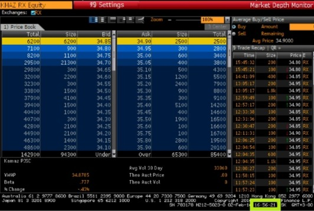

# Вывод

Восстановление стакана заявок по истоическим данным является актуальной задачей для биржевых аналитиков, так как с помошью него можно анализировать спреды и глубину рынка. Но информация по стаканам достпуна только в режиме реального времени . Возможность восстановления стакана, позволит проводить более глубокий анализ исторических данных.